# act_report_Folasade_Adeyanju_Project2

## Report: act_report

Follwoing the Data Wrangling Process which included the gathering, assessing and cleaning stages, the clean master dataset created was then analysed to develop insights.

To analyse the cleaned data I looked at answering a few questions;  
In what Year did we have the highest Tweets?

> Fig(1) - Distribution of tweets by year; shows that we have the highest count of tweets in the year 2016; this might have been affected by some of the data cleaning process (some rows were dropped such as the retweets and tweets with no images). Another factor could be that the dataset used only had data for up till August 2017 (affecting the count we see for 2017). However based on the requirements and dataset available, the year 2016 is the year that had the most original tweets with images.  
> The multiple bar chart (fig 2) displayed the retweet and like counts side by side by year. The count of likes is higher than that of retweets but the distribution by year is similar for both cases.

##### fig(1)

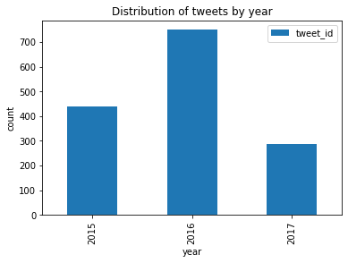

##### fig(2)

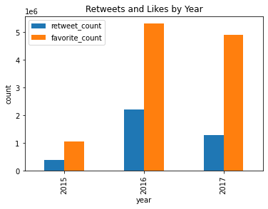

Which of the dog breeds are most liked?

> The most liked dog breed is the Golden Retriever. The horizontal bar plot (fig 3) shows the Top 10 most liked breed by their favorite count. The Top 4 most liked breeds also happen to be the most retweeted in that same order. This observation led us to check if there could be a correlation between retweet and likes.

##### fig(3)

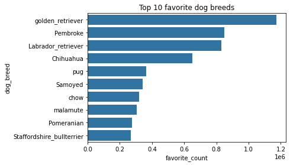

##### fig(4)

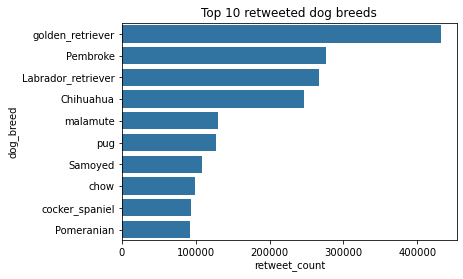

Is there any correlation between retweets and Likes?

> Calculating the correlation between retweets and likes using the correlation function, I got a strong positive correlation of 0.79. The scatter plot below somewhat suggests that the higher the count of likes, the more the retweets. This is however not enough for us to conclude that there is a relationship between the two, further analysis should be done to further establish or disprove what this data is telling us.

##### fig(5)

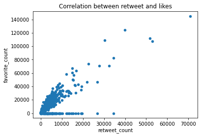

What is the average confidence prediction level of the dog breed in the dataset?

> Finally, by calculating the mean of the confidence prediction of the dataset, the average confidence level of the algorithm used for predictions in this dataset was about 61.4%

In Summary, now that all the questions have been answered, the data wrangling and analysis process almost never seems to be completely finished. There is usually a need to go back, add something or remove something. The data in this clean dataset suggests that the fluffy Golden Retrievers are the most liked dog breeds and that there is a strong correlation between retweets and likes. It would definitely be a treat to explore a larger dataset and to truly explore any relationships between retweets and likes.

##### Limitation

Having access to more data could give a more robust analysis and even more insights.